# Cesarean delivery rates

Problems, potential problems and caveats

> If we look by PUBLIC_HEALTH_REGION then we’ll need to clean up that data. there are NA’s. PROVIDER_NAME may change over time. “CHRISTUS Southeast Texas - St Elizabeth” is an example.

Working out Cesarean delivery rates by hospital (and later quarter)

```r
library(tidyverse)
library(janitor)
library(readxl)
library(DT)
library(plotly)
```

## Import needed files

- deliveries processed from 01-process-loop.
- facilities from 1q2018 facilities file

```r
deliveries <- read_rds("data-processed/ahrq_del_ucmp.rds")

deliveries_cnt <- deliveries %>% nrow()
paste("Total uncomplicated deliveries:", deliveries_cnt)
```

```
## [1] "Total uncomplicated deliveries: 993400"
```

```r
deliveries %>%
  select(THCIC_ID, PROVIDER_NAME) %>%
  distinct() %>%
  arrange(PROVIDER_NAME) %>%
  write_csv("data-processed/facility-list.csv")
```

## Set up the Cesarean values

These are from AHRQ Inpatient Quality Indicator 21 (IQI 21) Cesarean Delivery Rate, Uncomplicated

Number of Cesarean deliveries among cases meeting the inclusion and exclusion rules for the denominator. Cesarean deliveries are identified by either:

- MS-DRG codes for Cesarean delivery (PRCSE2G* ) or
- any-listed ICD-10-PCS procedure codes for Cesarean delivery (PRCSECP* ) and without any-listed ICD-10-PCS procedure codes for hysterotomy (PRCSE2P* ).

Here we create CBIRTH using the first method using MS-DRG.

```r
deliveries <- deliveries %>%
  mutate(
    CBIRTH = ifelse(
      MS_DRG %in% c("765", "766"), "Y", "N"
    )
  )
```

Overall Cesarean rate for the data set.

```r
deliveries %>%
  tabyl(CBIRTH) %>%
  rename(CNT = n, PRCT = percent)%>%
  adorn_pct_formatting()
```

| CBIRTH | CNT | PRCT |
| --- | --- | --- |
| N | 665827 | 67.0% |
| Y | 327573 | 33.0% |

## Cesarean rate per hospital, 2016-2018

```r
crate_all <- deliveries %>%
  group_by(PROVIDER_NAME, CBIRTH) %>%
  summarize(CNT = n()) %>%
  pivot_wider(names_from = CBIRTH, values_from = CNT) %>%
  filter(N >= 100) %>%
  mutate(
    CRATE = round((Y / (N+Y)) * 100,1)
  ) %>%
  arrange(CRATE %>% desc())

# writing out for use in separate file
crate_all %>% write_rds("data-processed/create_all.rds")

crate_all %>%
  datatable()
```

|  | PROVIDER_NAME | N | Y | CRATE |
| --- | --- | --- | --- | --- |
| 1 | Valley Regional Medical Center | 2809 | 3250 | 53.6 |
| 2 | Doctors Hospital-Laredo | 2586 | 2833 | 52.3 |
| 3 | Valley Baptist Medical Center-Brownsville | 2460 | 2475 | 50.2 |
| 4 | Cuero Regional Hospital | 107 | 105 | 49.5 |
| 5 | The Hospitals of Providence Sierra Campus | 1130 | 1096 | 49.2 |
| 6 | Mainland Medical Center | 124 | 116 | 48.3 |
| 7 | CHRISTUS Southeast Texas - St Elizabeth | 1792 | 1651 | 48 |
| 8 | CHI St Lukes Health - Memorial Livingston | 392 | 351 | 47.2 |
| 9 | CHRISTUS St Elizabeth Hospital | 929 | 802 | 46.3 |
| 10 | Laredo Medical Center | 5115 | 4135 | 44.7 |

[output cut: 258 more lines]

> There are some issues here with PROVIDER_NAME, as perhaps they changed over time. I might need to use the THCIC_ID and then use the 2018 facility names.

## Cesarean rates by hospital, quarter

```r
crate_q <- deliveries %>%
  group_by(DISCHARGE, PROVIDER_NAME, CBIRTH) %>%
  summarize(CNT = n()) %>%
  pivot_wider(names_from = CBIRTH, values_from = CNT) %>%
  filter(N >= 100) %>%
  mutate(
    CRATE = round((Y / (N+Y)) * 100,1)
  ) %>%
  arrange(CRATE %>% desc())

crate_q %>% head(2)
```

| DISCHARGE | PROVIDER_NAME | N | Y | CRATE |
| --- | --- | --- | --- | --- |
| 2017Q1 | Valley Regional Medical Center | 191 | 266 | 58.2 |
| 2016Q4 | Valley Regional Medical Center | 231 | 318 | 57.9 |

Make a list of specific hospitals we’ll track

```r
deliveries %>%
  filter(
    str_detect(PROVIDER_NAME, "Laredo")
  ) %>%
  select(PROVIDER_NAME) %>%
  distinct()
```

| PROVIDER_NAME |
| --- |
| Doctors Hospital-Laredo |
| Laredo Medical Center |

```r
st_list <- c(
    "Doctors Hospital-Laredo",
    "Laredo Medical Center",
    "Doctors Hospital-Renaissance",
    "Edinburg Regional Medical Center",
    "Valley Regional Medical Center",
    "Citizens Medical Center",
    "University Hospital",
    "Yoakum Community Hospital",
    "Yoakum County Hospital",
    "DeTar Hospital-Navarro",
    "DeTar Hospital-North"
)
```

Track some hospitals over time

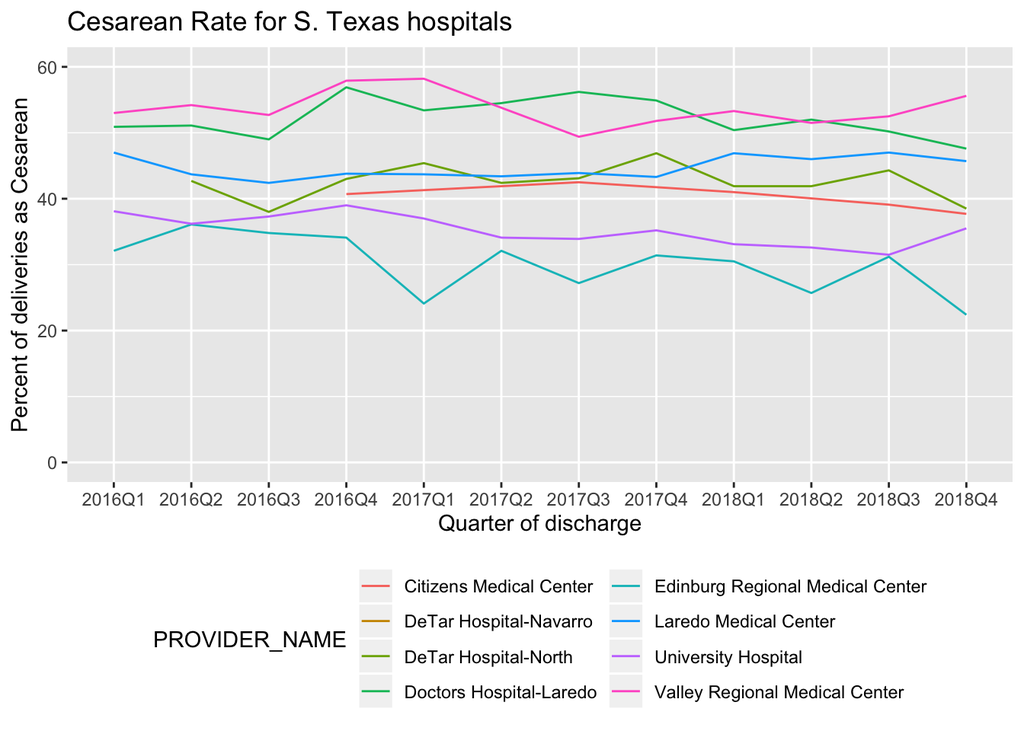

```r
plot_data <- crate_q %>%
  filter(
    PROVIDER_NAME %in% st_list
  ) %>%
  select(DISCHARGE, PROVIDER_NAME, CRATE)

crate_all_plot <- plot_data %>%
  ggplot(aes(DISCHARGE, CRATE)) +
  geom_line(aes(group = PROVIDER_NAME, color = PROVIDER_NAME)) +
  expand_limits(y = c(0,60)) +
  theme(legend.position="bottom", legend.box = "vertical") +
  guides(col = guide_legend(nrow = 4)) +
  labs(title = "Cesarean Rate for S. Texas hospitals", x = "Quarter of discharge", y = "Percent of deliveries as Cesarean")

crate_all_plot
```

## Working with PAT_COUNTY

### Get county fips

```r
counties <- read_excel("resources/PHR_MSA_County_masterlist.xlsx") %>% clean_names()
```

To be thorough, I would like to create a new Cesarean measure using the second method described by AHRQ:

- any-listed ICD-10-PCS procedure codes for Cesarean delivery (PRCSECP* ) and without any-listed ICD-10-PCS procedure codes for hysterotomy (PRCSE2P* ).

This is a little more involved and I haven’t quite figured it out yet.

```r
prcsecp <- c(
  "10D00Z0", "10D00Z1", "10D00Z2"
)

prcse2p <- c(
  "10A00ZZ", "10A03ZZ", "10A04ZZ"
)

# vector of procedure columns
surg_proc <- deliveries %>%
  select(contains("SURG_PROC_CODE")) %>% names()

# filters deliveries by surg_proc with prcsecp values
deliveries %>%
  filter_at(
    vars(surg_proc),
    any_vars(. %in% prcsecp)
  ) %>%
  select(surg_proc) %>%
  head()
```

| PRINC_SURG_PROC_CODE | OTH_SURG_PROC_CODE_1 | OTH_SURG_PROC_CODE_2 | OTH_SURG_PROC_CODE_3 | OTH_SURG_PROC_CODE_4 | OTH_SURG_PROC_CODE_5 | OTH_SURG_PROC_CODE_6 | OTH_SURG_PROC_CODE_7 | OTH_SURG_PROC_CODE_8 | OTH_SURG_PROC_CODE_9 | OTH_SURG_PROC_CODE_10 | OTH_SURG_PROC_CODE_11 | OTH_SURG_PROC_CODE_12 | OTH_SURG_PROC_CODE_13 | OTH_SURG_PROC_CODE_14 | OTH_SURG_PROC_CODE_15 | OTH_SURG_PROC_CODE_16 | OTH_SURG_PROC_CODE_17 | OTH_SURG_PROC_CODE_18 | OTH_SURG_PROC_CODE_19 | OTH_SURG_PROC_CODE_20 | OTH_SURG_PROC_CODE_21 | OTH_SURG_PROC_CODE_22 | OTH_SURG_PROC_CODE_23 | OTH_SURG_PROC_CODE_24 |
| --- | --- | --- | --- | --- | --- | --- | --- | --- | --- | --- | --- | --- | --- | --- | --- | --- | --- | --- | --- | --- | --- | --- | --- | --- |
| 10D00Z1 | NA | NA | NA | NA | NA | NA | NA | NA | NA | NA | NA | NA | NA | NA | NA | NA | NA | NA | NA | NA | NA | NA | NA | NA |
| 10D00Z1 | NA | NA | NA | NA | NA | NA | NA | NA | NA | NA | NA | NA | NA | NA | NA | NA | NA | NA | NA | NA | NA | NA | NA | NA |
| 10D00Z1 | NA | NA | NA | NA | NA | NA | NA | NA | NA | NA | NA | NA | NA | NA | NA | NA | NA | NA | NA | NA | NA | NA | NA | NA |
| 10D00Z1 | NA | NA | NA | NA | NA | NA | NA | NA | NA | NA | NA | NA | NA | NA | NA | NA | NA | NA | NA | NA | NA | NA | NA | NA |
| 10D00Z1 | NA | NA | NA | NA | NA | NA | NA | NA | NA | NA | NA | NA | NA | NA | NA | NA | NA | NA | NA | NA | NA | NA | NA | NA |
| 10D00Z1 | NA | NA | NA | NA | NA | NA | NA | NA | NA | NA | NA | NA | NA | NA | NA | NA | NA | NA | NA | NA | NA | NA | NA | NA |

```r
# looks through only one column for precsecp and sets it
# but I need to look through all of them.
deliveries %>%
  mutate(
    CBIRTH2 = if_else(
      PRINC_SURG_PROC_CODE %in% prcsecp,
      "Y", "F"
    )
  ) %>%
  count(CBIRTH2)
```

| CBIRTH2 | n |
| --- | --- |
| F | 670261 |
| Y | 323139 |

```r
# deliveries %>%
#   mutate(
#     CBIRTH2 = if_else(
#       surg_proc %in% prcsecp, "Y", "F"
#     )
#   )
```

## Complete

```r
beepr::beep(4)
```